# Interaction Effects

EC 325: Econometrics

Prof. Caraher

Colby College

Oct 29, 2026

## Why Interactions?

- Last unit: a dummy shifts the **intercept** but keeps the **same slope**

$$\widehat{wage} = \hat{\beta}_0 + \hat{\beta}_1(female) + \hat{\beta}_2(educ)$$

- But maybe education pays off differently for men and women, so the gender gap changes with education
- We need the **effect** of one variable to **depend on** the value of another

**Interaction Effects**

Include the *product* of two variables in the regression.

# Interactions Between Two Dummies

## Setting Up the Model

- Suppose we want to understand how **gender** and **marital status** jointly affect wages
- We can estimate this relationship using an **interaction term**:

$$\ln(wage) = \beta_0 + \beta_1(female) + \beta_2(married) + \beta_3(female \times married) + \mu$$

- $female \times married$ is the **interaction term**
- It equals **1** only when *both* are true (the person is female AND married)
- It equals **0** for everyone else

## Identifying the Baseline

- With dummy variables, interactions or not, we always need a **baseline group** to interpret the coefficients: the group where all dummies equal zero
- **How to find it:** set every dummy to 0 and say what each 0 means
  - $female = 0$ → men; $married = 0$ → unmarried (interaction will also obviously be zero)
- Here, the baseline is **unmarried men** ($female = 0$, $married = 0$)
- $\beta_0$ is the average $\ln(wage)$ for this baseline group
- Every other coefficient is an effect **relative to unmarried men**

**Key Habit**

Before interpreting any coefficient, always ask: *who is the baseline?.* It might be hard to do if you don’t know all the different options a variable can take!

## What is $\hat{y}$ equal to ?

| Group | female | married | Predicted $\ln(wage)$ |
| --- | --- | --- | --- |
| Unmarried men (baseline) | 0 | 0 | $\beta_0$ |
| Unmarried women | 1 | 0 | $\beta_0 + \beta_1$ |
| Married men | 0 | 1 | $\beta_0 + \beta_2$ |
| Married women | 1 | 1 | $\beta_0 + \beta_1 + \beta_2 + \beta_3$ |

- $\beta_1$ = female vs. male, **among the unmarried**
- $\beta_2$ = married vs. unmarried, **among men**
- $\beta_3$ = the **additional** effect of being *both* female and married, beyond $\beta_1 + \beta_2$

## Let’s Estimate It

```r
wage_data <- wooldridge::wage1 |>
    mutate(female_married = female * married)

lm_interact <- lm(log(wage) ~ female + married + female_married, data = wage_data)
coef(lm_interact) |> round(3)
```

```
   (Intercept)         female        married female_married
         1.521         -0.132          0.427         -0.375
```

- A **premium** (**penalty**) is how much *higher* (*lower*) the outcome is for one group than for the group it’s compared to
- **Unmarried women** earn about 12% less than unmarried men
- **Married men** earn about 53% more than unmarried men ($\hat{\beta}_2$ is too big for the $100 \times \hat{\beta}$ shortcut)
- **Interaction** ($\hat{\beta}_3 \approx -0.375$, p < 0.001): the marriage premium is 0.427 for men but only 0.427 − 0.375 = 0.052 for women

## Practice: Turn to Your Neighbor

Consider this model of home prices:

$$\ln(price) = \beta_0 + \beta_1(sqft) + \beta_2(Pool) + \beta_3(Garage) + \beta_4(Pool \times Garage) + \mu$$

$Pool = 1$ if the house has a pool, 0 if not; $Garage = 1$ if it has a garage, 0 if not

**Discuss with your neighbor:**

1. Which houses are the baseline?
2. What does $\beta_2$ compare?
3. What does $\beta_3$ compare?
4. How much more is a house with a pool and a garage worth than a house with neither?

**Answers:**

1. Houses with no pool and no garage
2. Pool vs. no pool, among houses with **no garage**
3. Garage vs. no garage, among houses with **no pool**
4. $\beta_2 + \beta_3 + \beta_4$

## Hint: Compare Two Groups by Subtracting

1. **Plug in** each group’s 0s and 1s
2. **Subtract** one from the other: everything the two groups share cancels
3. **What’s left** is the comparison!

**Example:** garage vs. no garage, among houses **with** a pool (same $sqft$)

$$\begin{array}{lcl}
\text{Pool, garage } (1, 1): & & \beta_0 + \beta_1 sqft + \beta_2 + \beta_3 + \beta_4 \\
\text{Pool, no garage } (1, 0): & - & (\beta_0 + \beta_1 sqft + \beta_2) \\
\hline
\text{Difference:} & & \beta_3 + \beta_4
\end{array}$$

**Shortcut**

The answer is the coefficients that are “on” for one group but not the other.

# Dummy × Continuous Interactions

## Different Slopes for Different Groups

- What if we want the **return to education** to differ by gender?

$$\ln(wage) = \beta_0 + \beta_1(female) + \beta_2(educ) + \beta_3(female \times educ) + \mu$$

- $female \times educ$ = 0 for all men, and = `educ` for all women
- This gives each group a **different intercept AND slope**:

## Two Separate Regression Lines

**Men** ($female = 0$):
$$\ln(wage) = \beta_0 + \beta_2(educ)$$

**Women** ($female = 1$):
$$\ln(wage) = \underbrace{(\beta_0 + \beta_1)}_{\text{different intercept}} + \underbrace{(\beta_2 + \beta_3)}_{\text{different slope}}(educ)$$

- $\beta_1$ = **intercept** difference: the gap at $educ = 0$, outside the data
- $\beta_3$ = **slope** difference (how much more/less women gain per year of education)

**vs. Dummy-Only Model**

Without the interaction, both groups share the **same slope** (parallel lines). The interaction lets the lines have **different slopes** — they can converge, diverge, or even cross.

## Simulated Example

To see this clearly, let’s generate data where the difference is obvious:

- Men: 8% return to education; Women: 14% return
- Women start with a lower intercept

```r
set.seed(42)
n <- 500

sim_data <- tibble(
    female = rep(c(0, 1), each = n/2),
    educ = round(runif(n, min = 8, max = 20)),
    error = rnorm(n, mean = 0, sd = 0.4),
    lwage = 0.8 - 0.90 * female + 0.08 * educ + 0.06 * female * educ + error
) |>
    mutate(female_educ = female * educ)
```

## Estimating the Model

```r
lm_slope <- lm(lwage ~ female + educ + female_educ, data = sim_data)
coef(lm_slope) |> round(3)
```

```
(Intercept)      female        educ female_educ
      0.737      -0.774       0.083       0.050
```

- Return to education for **men**: $\hat{\beta}_2 \approx 0.083$ → 8.3% per year
- Return to education for **women**: $\hat{\beta}_2 + \hat{\beta}_3 \approx 0.134$ → 13.4% per year
- The **interaction** ($\hat{\beta}_3 \approx 0.05$): women gain 5 percentage points *more* per year of education
- In the **real** `wage1` data: $\hat{\beta}_3 = -0.0001$ (p = 0.996), so no evidence the return to education differs by gender

## Side-by-Side: Dummy-Only vs. Interaction

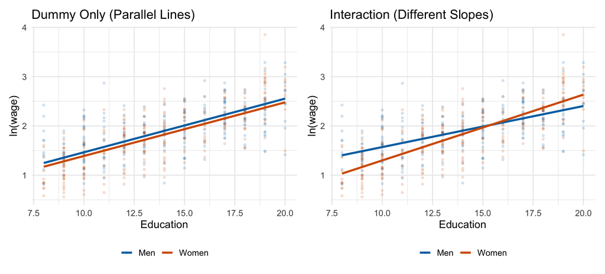

- With the interaction the lines are **not parallel**; here they cross at about 15 years of education

## The General Rule

When interactions are present, the **total effect** of a variable includes all terms where it appears:

$$\ln(wage) = \beta_0 + \beta_1(female) + \beta_2(educ) + \beta_3(female \times educ) + \mu$$

- Effect of education: $\frac{\partial \ln(wage)}{\partial educ} = \beta_2 + \beta_3(female)$
  - For men: $\beta_2$
  - For women: $\beta_2 + \beta_3$
- Gender wage gap ($female$: 0 → 1): $\beta_1 + \beta_3(educ)$
  - **Depends on education level!**

## The Gender Gap at Different Education Levels (Simulated)

```r
educ_levels <- c(8, 10, 12, 14, 16, 18)

tibble(
    `Education` = educ_levels,
    `Gender gap (log pts)` = round(slope_coefs[2] + slope_coefs[4] * educ_levels, 3),
    `% gap` = round(100 * (exp(slope_coefs[2] + slope_coefs[4] * educ_levels) - 1), 1)
) |> knitr::kable()
```

| Education | Gender gap (log pts) | % gap |
| --- | --- | --- |
| 8 | -0.372 | -31.0 |
| 10 | -0.271 | -23.7 |
| 12 | -0.170 | -15.7 |
| 14 | -0.070 | -6.8 |
| 16 | 0.031 | 3.1 |
| 18 | 0.131 | 14.0 |

**Common Mistake**

Never report just the main effect $\beta_1$ as “the effect of being female.” With an interaction, the true effect is $\beta_1 + \beta_3(educ)$ — it depends on education!

# Why You Need Main Effects

## What Goes Wrong Without Them?

What if we *only* include the interaction: $\ln(wage) = \beta_0 + \beta_1(female \times married) + \mu$?

```r
lm_wrong <- lm(log(wage) ~ female_married, data = wage_data)
```

|  | Correct | Interaction Only |
| --- | --- | --- |
| Female | -0.1316** |  |
|  | (0.0668) |  |
| Married | 0.4267*** |  |
|  | (0.0616) |  |
| Female × Married | -0.3748*** | -0.2432*** |
|  | (0.0857) | (0.0524) |
| Constant | 1.5208*** | 1.6843*** |
|  | (0.0510) | (0.0263) |
| Num.Obs. | 526 | 526 |
| R2 Adj. | 0.209 | 0.038 |

* p < 0.1, ** p < 0.05, *** p < 0.01

## What Can Each Model Predict?

| Group | Correct: Formula | Correct: Value | Wrong: Formula | Wrong: Value |
| --- | --- | --- | --- | --- |
| Unmarried men | β₀ | 1.521 | β₀ | 1.684 |
| Unmarried women | β₀ + β₁ | 1.389 | β₀ | 1.684 |
| Married men | β₀ + β₂ | 1.947 | β₀ | 1.684 |
| Married women | β₀ + β₁ + β₂ + β₃ | 1.441 | β₀ + β₁ | 1.441 |

- The interaction-only model gives the **same prediction** to unmarried men, unmarried women, and married men — it can’t tell them apart!
- It lumps every group *except married women* into one baseline

**Always Include the Main Effects**

When you include $X_1 \times X_2$, **always** include $X_1$ and $X_2$ too.

## Key Takeaways

1. **Interaction terms** = the product of two variables on the RHS
2. **Dummy × Dummy**: the combination of two characteristics may have an effect ≠ sum of individual effects
3. **Dummy × Continuous**: allows different **slopes** (not just different intercepts) for each group
4. **Total effects** must include all terms where a variable appears — don’t just report the main effect!
5. **Always include the main effects** alongside the interaction term